# Descriptives Statistics & Probability Distributions

Lecture 2 - LAS

Don van den Bergh

2028-07-08

## Today

[Chapter 2](https://cjvanlissa.github.io/stats12/chapter2_descriptive_statistics.html) and [Chapter 4](https://cjvanlissa.github.io/stats12/probability.html) from the gitbook.

**Mistake in slide from last week!**

- Deadline assignment #1 is Sunday October 18th.
- Deadline on Canvas is always guiding!

# Descriptives Statistics

## Why do We use Descriptives Statistics?

- to describe the sample
- to check for mistakes (attention check)
- to check assumptions
- to answer research questions that do not require hypothesis tests

## When do We use Descriptives Statistics?

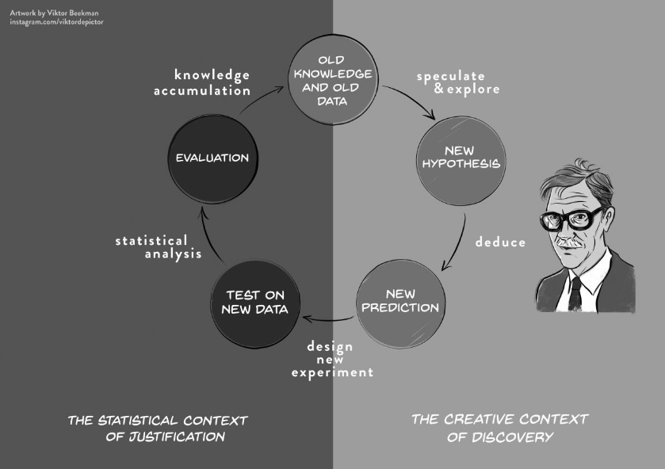

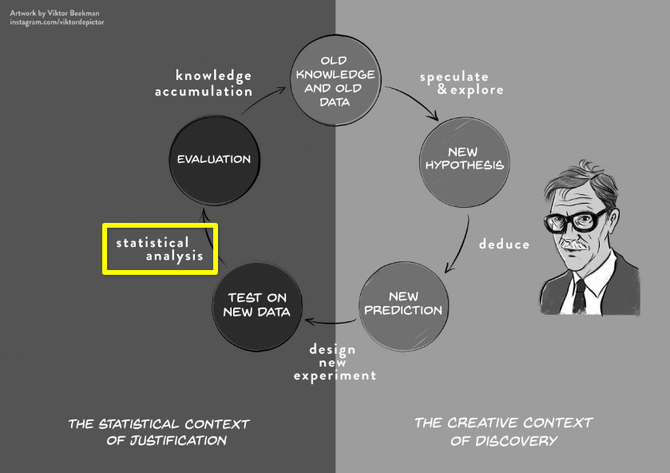

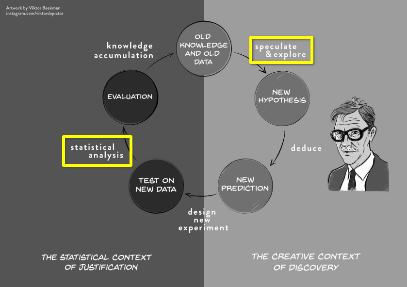

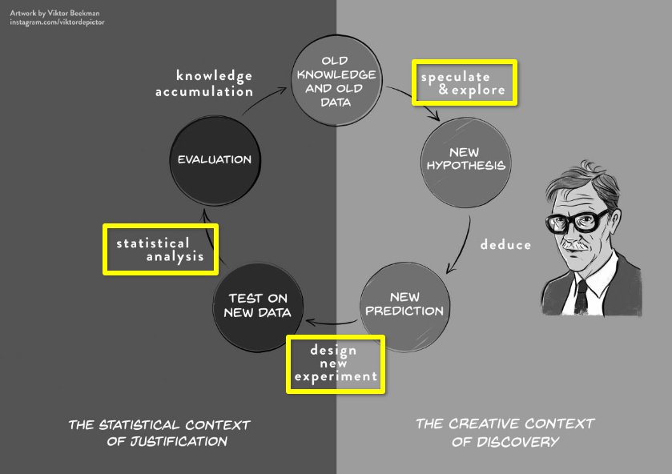

Source: Wagenmakers, E. J., Dutilh, G., & Sarafoglou, A. (2018). The creativity-verification cycle in psychological science: New methods to combat old idols. , 13(4), 418-427. https://doi.org/10.1177/1745691618771357

## Descriptives Statistics Today

- Central Tendency
- Dispersion/ Spread/ Variability
- Skewness
- Kurtosis

## Data Example: Bechdel Test

## Data Example: Bechdel Test

| year | imdb | title | test | clean_test | binary | budget | domgross | intgross | code | budget_2013. | domgross_2013. | intgross_2013. | period.code | decade.code |
| --- | --- | --- | --- | --- | --- | --- | --- | --- | --- | --- | --- | --- | --- | --- |
| 2013 | tt1711425 | 21 &amp; Over | notalk | notalk | FAIL | 13000000 | 25682380 | 42195766 | 2013FAIL | 13000000 | 25682380 | 42195766 | 1 | 1 |
| 2012 | tt1343727 | Dredd 3D | ok-disagree | ok | PASS | 45000000 | 13414714 | 40868994 | 2012PASS | 45658735 | 13611086 | 41467257 | 1 | 1 |
| 2013 | tt2024544 | 12 Years a Slave | notalk-disagree | notalk | FAIL | 20000000 | 53107035 | 158607035 | 2013FAIL | 20000000 | 53107035 | 158607035 | 1 | 1 |
| 2013 | tt1272878 | 2 Guns | notalk | notalk | FAIL | 61000000 | 75612460 | 132493015 | 2013FAIL | 61000000 | 75612460 | 132493015 | 1 | 1 |
| 2013 | tt0453562 | 42 | men | men | FAIL | 40000000 | 95020213 | 95020213 | 2013FAIL | 40000000 | 95020213 | 95020213 | 1 | 1 |
| 2013 | tt1335975 | 47 Ronin | men | men | FAIL | 225000000 | 38362475 | 145803842 | 2013FAIL | 225000000 | 38362475 | 145803842 | 1 | 1 |
| 2013 | tt1606378 | A Good Day to Die Hard | notalk | notalk | FAIL | 92000000 | 67349198 | 304249198 | 2013FAIL | 92000000 | 67349198 | 304249198 | 1 | 1 |
| 2013 | tt2194499 | About Time | ok-disagree | ok | PASS | 12000000 | 15323921 | 87324746 | 2013PASS | 12000000 | 15323921 | 87324746 | 1 | 1 |
| 2013 | tt1814621 | Admission | ok | ok | PASS | 13000000 | 18007317 | 18007317 | 2013PASS | 13000000 | 18007317 | 18007317 | 1 | 1 |
| 2013 | tt1815862 | After Earth | notalk | notalk | FAIL | 130000000 | 60522097 | 244373198 | 2013FAIL | 130000000 | 60522097 | 244373198 | 1 | 1 |

[output cut: 20 more lines]

[Source](https://github.com/fivethirtyeight/data/blob/4c1ff5e3aef1816ae04af63218015066e186c147/bechdel/movies.csv)

## Measures of Central Tendency

The most “common” value, one “representative” number

- average student
- most popular show on Netflix
- proportion of movies that passes the bechdel test
- average movie budget
- most common bechdel test result

## Central Tendency: Mean

$$\bar{x} = \frac{\sum_{i=1}^{n}x_i}{n} = \frac{x_1 + x_2 +\, ... + x_n}{n}$$

Definitions:

- $x$: the variable we’re interested in.
- $\bar{x}$: the sample mean of the variable
- $x_i$: the $i$th observation of the variable.
- $n$ the sample size.
- $\sum_{i=1}^{n}$: the sum from $i$ is 1 to $i$ is $n$.

## Central Tendency: Mean

Let’s call “PASS” 1 and “FAIL” 0.

What does the mean of these numbers compute?

The proportion of movies that passed the Bechdel test.

No. “PASS” (803) / No. Movies (1794) = 0.448

## Central Tendency: Mean

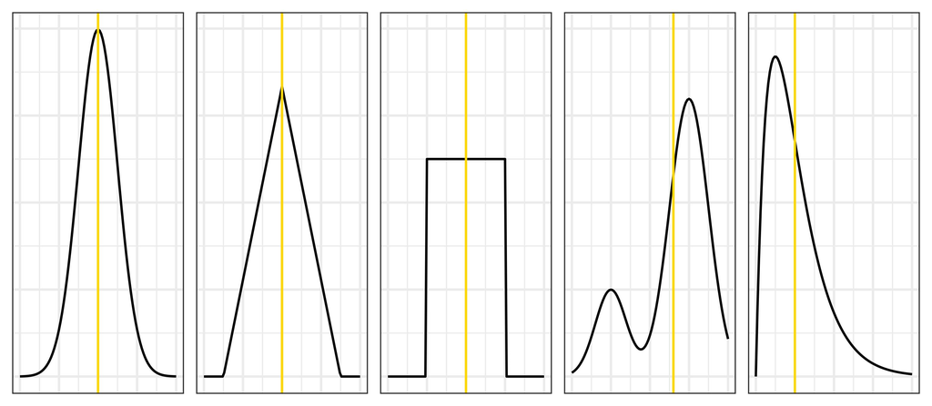

## Central Tendency: Median

**Definition: Median**

If you were to order all scores of your variable from lowest to highest, then the median value is the value that splits your sample in half: half of the participants score lower than this value, and half score higher.

- Another name for the median is the 50th percentile. The nth percentile is the score that divides the sample so that % of participants score lower.
- If the distribution is symmetric, then the median equals the mean

## Central Tendency: Median

| Year | Freq |
| --- | --- |
| 1970 | 1 |
| 1971 | 5 |
| 1972 | 3 |
| 1973 | 5 |
| 1974 | 7 |
| 1975 | 5 |
| 1976 | 8 |
| 1977 | 7 |
| 1978 | 8 |
| 1979 | 5 |
| 1980 | 14 |
| 1981 | 9 |
| 1982 | 14 |
| 1983 | 5 |
| 1984 | 16 |
| 1985 | 10 |
| 1986 | 10 |
| 1987 | 14 |
| 1988 | 19 |
| 1989 | 14 |
| 1990 | 15 |
| 1991 | 13 |
| 1992 | 20 |
| 1993 | 16 |
| 1994 | 26 |
| 1995 | 36 |
| 1996 | 42 |
| 1997 | 51 |
| 1998 | 62 |
| 1999 | 56 |
| 2000 | 63 |
| 2001 | 64 |
| 2002 | 80 |
| 2003 | 64 |
| 2004 | 81 |
| 2005 | 100 |
| 2006 | 90 |
| 2007 | 73 |
| 2008 | 101 |
| 2009 | 124 |
| 2010 | 129 |
| 2011 | 124 |
| 2012 | 86 |
| 2013 | 99 |

## Central Tendency: Median

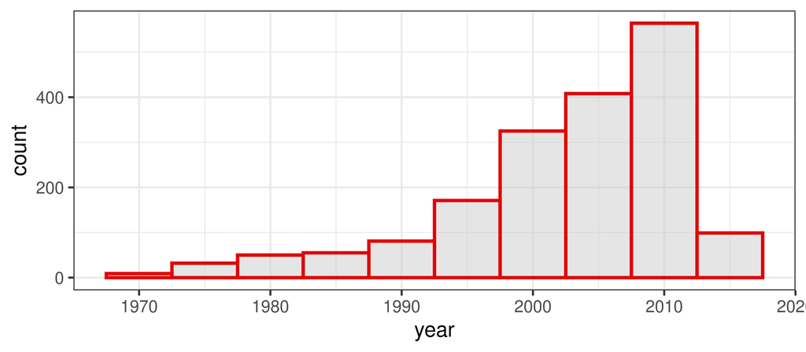

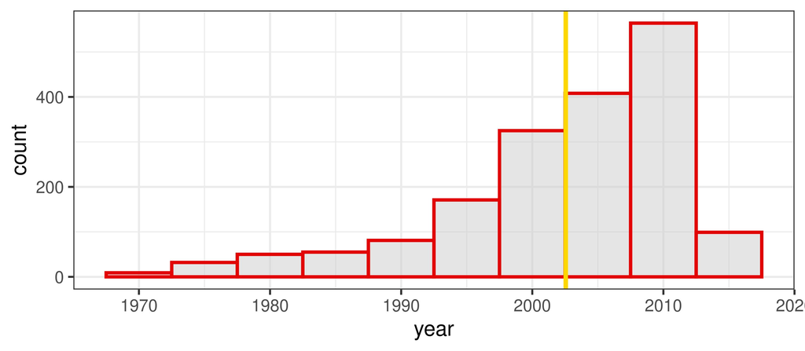

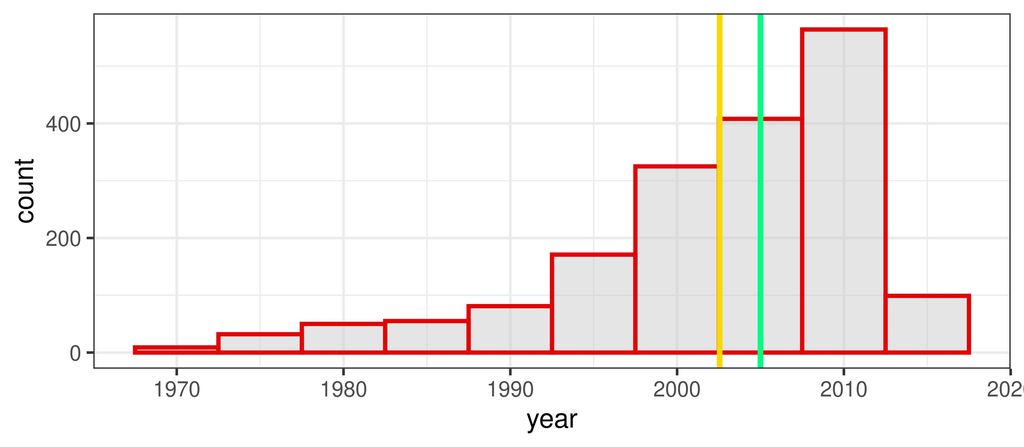

## Central Tendency: Median

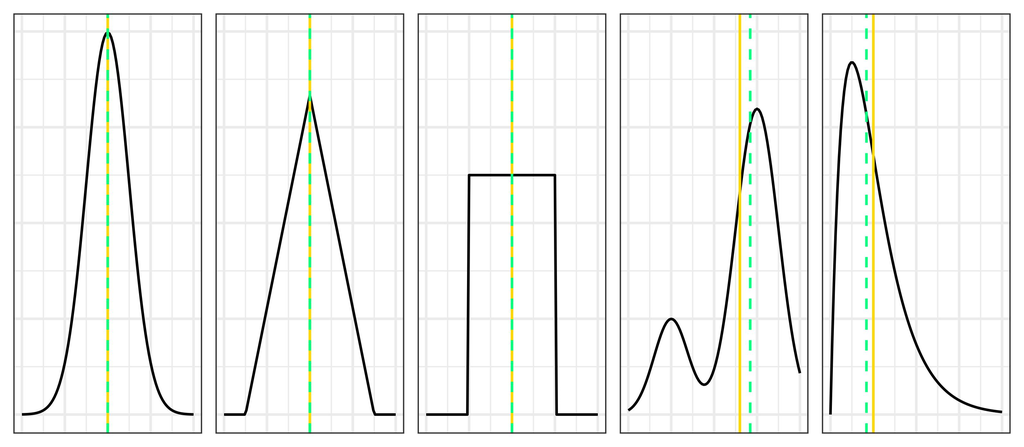

## Central Tendency: Mode

- The most common value

## Central Tendency: Mode

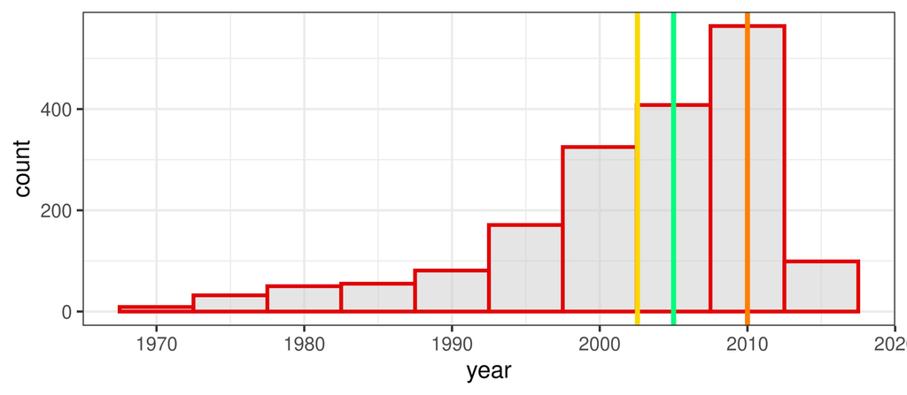

## Dispersion

- Range
- Sum of Squared Distances to the Mean
- Variance: mean squared distance
- Standard Deviation
- Mean absolute deviation (MAD)

## Range

$$R = x_{\mathrm{largest}} - x_{\mathrm{smallest}}$$

$R_\mathrm{year}$: 2013 $-$ 1970 $=$ 43.

## Sum of Squared Distances to the Mean: $SS_x$

$$\begin{align}
\bar{x} &= \frac{\sum_{i=1}^{n}x_i}{n} &&= \frac{x_1 + x_2 +\, ... + x_n}{n}\\
SS_x &= \sum_{i=1}^{n}(x_i - \bar{x})^2 &&= (x_1 -\bar{x})^2 + (x_2 -\bar{x})^2 +\, ... + (x_n -\bar{x})^2
\end{align}$$

- $\overline{\mathrm{year}} =$ 2002.5523969
- $SS_{\mathrm{year}} =$ 144579.6

## Variance: mean squared distance

$$\begin{align}
\bar{x} &= \frac{\sum_{i=1}^{n}x_i}{n} &&= \frac{x_1 + x_2 +\, ... + x_n}{n}\\
SS_x &= \sum_{i=1}^{n}(x_i - \bar{x})^2 &&= (x_1 -\bar{x})^2 + (x_2 -\bar{x})^2 +\, ... + (x_n -\bar{x})^2\\
s^2_x &= \frac{SS_x}{n}&&
\end{align}$$

- $\overline{\mathrm{year}} =$ 2002.5523969
- $SS_{\mathrm{year}} =$ 144579.6
- $s^2_{\mathrm{year}} =$ 80.5906213

## Standard Deviation: root mean squared distance

$$\begin{align}
\bar{x} &= \frac{\sum_{i=1}^{n}x_i}{n} &&= \frac{x_1 + x_2 +\, ... + x_n}{n}\\
SS_x &= \sum_{i=1}^{n}(x_i - \bar{x})^2 &&= (x_1 -\bar{x})^2 + (x_2 -\bar{x})^2 +\, ... + (x_n -\bar{x})^2\\
s^2_x &= \frac{SS_x}{n}&&\\
s_x &= \sqrt{s^2_x}&&
\end{align}$$

- $\overline{\mathrm{year}}$ = 2002.5523969
- $SS_{\mathrm{year}}$ = 144579.6
- $s^2_{\mathrm{year}}$ = 80.5906213
- $s_{\mathrm{year}}$ = 8.9772279

## Mean absolute deviation (MAD)

$$\mathrm{MAD}_{x} = \frac{\sum_{i=1}^{n}|x_i - \bar{x}|}{n} = \frac{|x_1 -\bar{x}| + |x_2 -\bar{x}| +\, ... + |x_n -\bar{x}|}{n}\\$$

- $\mathrm{MAD}_{\mathrm{year}} =$ 6.9458004

## Skewness and Kurtosis

Mean

SD

Skewness

Kurtosis

## What have we learned?

- Most movies did not pass the Bechdel test.
- Most movies are from 2000 - 2010.
- The distribution of years is *left skewed*.

# Probability

## Population versus Sample

- The “Descriptive Statistics” before were doing inference on a sample.
- We will now see that each of these has a population counterpart.
- For this, we first need to some probability theory.

## Defining probability

**Probability:** How likely something is to occur.

- Specifically, the proportion of times we expect to observe an outcome in a *random experiment* that could be repeated many times

*Random experiment*

- Could theoretically be repeated an infinite number of times
- Before I flip a coin, the coinflip is a random experiment with $P_{heads} = .5$, or 50%
- After I flip the coin, it’s no longer random; it’s fixed (either 100% or 0%)

## Examples probability

Probability:

- of a baby being born male, $p_{male} = .51$
- of rolling a 7 with two dice in Catan, $p_7 = .167$

Not probability:

- The probability that there is life on other planets is either 100% or 0%
- Even if you don’t know which is correct

## Random variables

**Random variable**: An unknown value that follows some probability distribution.

*Disambiguation: Last lecture we used “variable” as a placeholder for some unknown number.*

- The outcome of a coin toss is a random variable
- It is discrete because it has only two possible outcomes
- The probability distributions is
  - P(X = heads) = 0.5
  - P(X = tails) = 0.5
  - Together: 1.0, so all possible outcomes are covered

# Break

See you in ~10 minutes!

# Discrete probability distributions

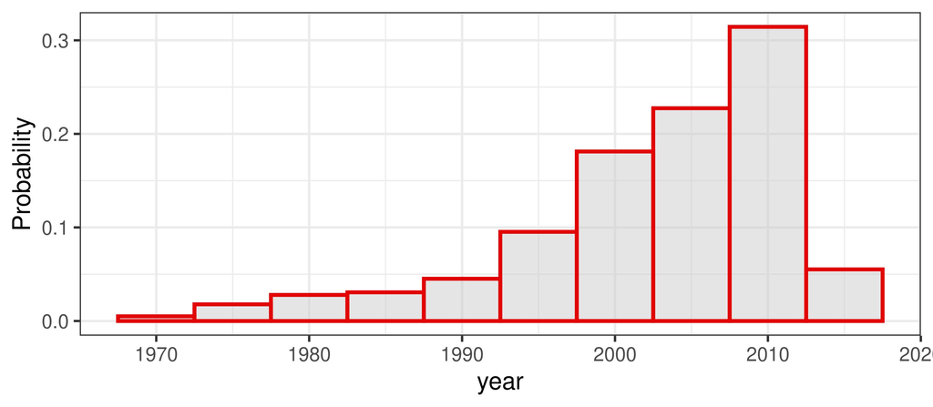

## Frequency vs probability

Frequency distributions

- Summarize observed outcomes in a sample
- E.g., the number of Dutch/foreign students in this class

A probability distribution is similar, but

- Can be interpreted as the (estimated) probability of observing these outcomes in the future
- E.g., if I select a random student in this class, what’s the probability that they will be Dutch?

## Discrete distributions

- Probability mass function (pmf)
  - 100% of the probability mass is distributed among finite discrete outcomes
- Discrete => Finite number of outcomes
  - Dutch student / foreign student
  - Student has tattoos / no tattoos
  - Movie passes/ fails the Bechdel test
  - Describe using contingency table or bar chart

|  | Gender Female | Gender Male | Gender Mixed/other | Total |  |
| --- | --- | --- | --- | --- | --- |
| Test |  |  |  |  |  |
| FAIL | 21 | 957 | 13 | 991 |  |
| PASS | 94 | 689 | 20 | 803 |  |
| Total | 115 | 1,646 | 33 | 1,794 |  |

## Indexing contingency tables

$i$: row

$j$: column

$f$: frequency (number of observations)

$f_{i,j}$: frequency in the cell in row $i$, column $j$

| \(i\) | $j$ \(j = 1\) | $j$ \(j = 2\) | **Margin rows** |
| --- | --- | --- | --- |
| \(i = 1\) | \(f_{1,1}\) | \(f_{1,2}\) | \(f_{1,+}\) |
| \(i = 2\) | \(f_{2,1}\) | \(f_{2,2}\) | \(f_{2,+}\) |
| **Margin columns** | \(f_{+,1}\) | \(f_{+,2}\) | \(f_{+,+}\) |

## Marginal frequency distribution

Separate frequency distribution of each variable in contingency table

| \(i\) | \(j\) \(j = 1\) | \(j\) \(j = 2\) | **Margin rows** |
| --- | --- | --- | --- |
| \(i = 1\) | \(f_{1,1}\) | \(f_{1,2}\) | \(f_{1,+}\) |
| \(i = 2\) | \(f_{2,1}\) | \(f_{2,2}\) | \(f_{2,+}\) |
| **Margin columns** | \(f_{+,1}\) | \(f_{+,2}\) | \(f_{+,+}\) |

## Marginal frequency distribution

For the variable “Gender”: How female directors?

For the variable “Test”: How many movies passed?

| Test | Director gender Female | Director gender Male | Director gender Mixed/other | Total row |
| --- | --- | --- | --- | --- |
| FAIL | 21 | 957 | 13 | 991 |
| PASS | 94 | 689 | 20 | 803 |
| **Total column** | 115 | 1646 | 33 | 1794 |

## Conditional frequency distribution

Frequency distribution of one variable, for specific value of the other variable

E.g.: What is the conditional frequency distribution of Gender **for movies that passed?**

| Test | Director gender Female | Director gender Male | Director gender Mixed/other | Total row |
| --- | --- | --- | --- | --- |
| FAIL | 21 | 957 | 13 | 991 |
| PASS | 94 | 689 | 20 | 803 |
| **Total column** | 115 | 1646 | 33 | 1794 |

## Joint frequency distribution

Frequency of a combination of two (or more) variables

E.g.: What is the frequency of **movies that passed with a male director**?

| Test | Director gender Female | Director gender Male | Director gender Mixed/other | Total row |
| --- | --- | --- | --- | --- |
| FAIL | 21 | 957 | 13 | 991 |
| PASS | 94 | 689 | 20 | 803 |
| **Total column** | 115 | 1646 | 33 | 1794 |

## Frequencies to probabilities

Divide frequencies by a total to get a probability distribution

Which frequencies and which total you use depends on what probability distribution you want

## Marginal probability distribution

Divide marginal totals by the global total

E.g.: What is the marginal probability distribution of a movie passing? $P(Pass)$

| Test | Director gender Female | Director gender Male | Director gender Mixed/other | Total row |
| --- | --- | --- | --- | --- |
| FAIL | 21 | 957 | 13 | 991 / 1794 = 0.55 |
| PASS | 94 | 689 | 20 | 803 / 1794 = 0.45 |
| **Total column** | 115 | 1646 | 33 | 1794 |

## Conditional probability distribution

Divide the row- or column frequencies by the marginal total

| Test | Director gender Female | Director gender Male | Director gender Mixed/other | Total row |
| --- | --- | --- | --- | --- |
| FAIL | 21 | 957 | 13 | 991 |
| PASS | 94 / 803 = 0.12 | 689 / 803 = 0.86 | 20 / 803 = 0.02 | 803 |
| **Total column** | 115 | 1646 | 33 | 1794 |

## Joint probability distribution

Divide the cell frequency by the global total

E.g.: What is the joint probability of a movie Passing and having a female director? $P(Pass \cap Female)$

| Test | Director gender Female | Director gender Male | Director gender Mixed/other | Total row |
| --- | --- | --- | --- | --- |
| FAIL | 21 | 957 | 13 | 991 |
| PASS | 94 / 1794 = 0.05 | 689 | 20 | 803 |
| **Total column** | 115 | 1646 | 33 | 1794 |

# Continuous probability distributions

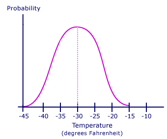

## Continuous probability distributions

- Infinite possible outcomes
- No exact probability for specific values
- Continuous *probability density function* describes how likely each outcome is
  - Cf. probability mass function for discrete outcomes
- Surface area determines probability
- Many probability distributions exist
- This course covers only one…

## Normal Distribution

Theoretical distribution for continuous variables

Bell-shaped, symmetric, from -infinity to +infinity

You can use it to describe (=model) real data

Two parameters:

- Mean $\mu$ (“mu”): Most common / average value
- Standard deviation $\sigma$ (“sigma”): Average deviation from the mean

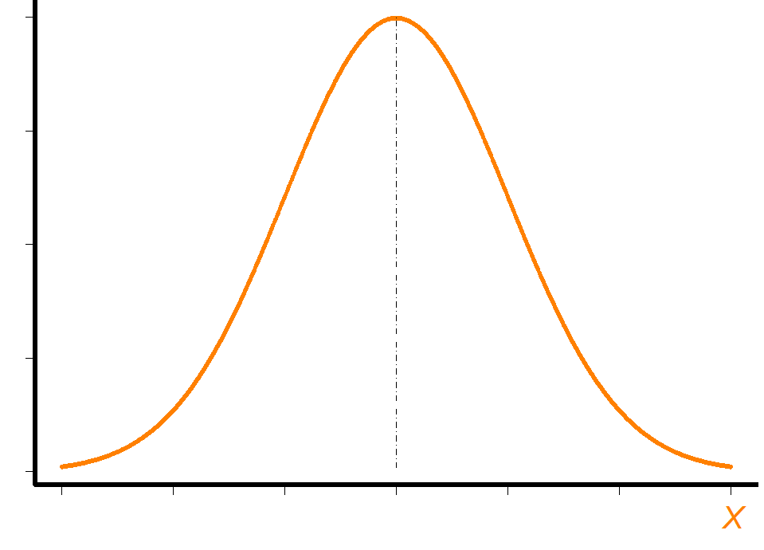

## Examples of Normal Distributions

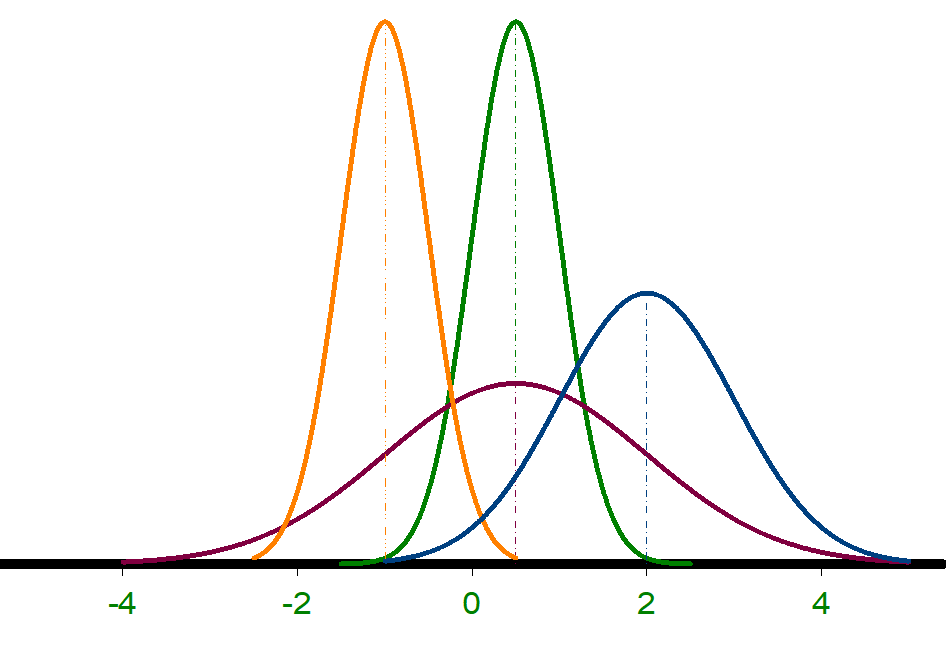

| Dist. | $\mu$ | $\sigma$ |
| --- | --- | --- |
| 1 | –1.0 | 0.5 |
| 2 | 0.5 | 0.5 |
| 3 | 0.5 | 1.5 |
| 4 | 2.0 | 1.0 |

## Normal Demo

μ

σ

## Standard Normal Distribution (Z-distribution)

$Z \sim N(\mu = 0, \sigma^2 = 1)$ Note $\sigma^2 = \sigma = 1$

- The normal distribution is *closed* under linear transformations.
  - i.e., if $Y~N(a, b)$ then $X = c \times Y + d \sim N(c\times a + d, c \times b)$.

Because of this:

- We can standardize any normal distribution to the *Z*-distribution
- This removes the units of measurement of our original variable
- Standardizing allows us to calculate probabilities more easily
- Stats books contain probability values for the Z-distribution
- We can always convert back to the original units

## Standard Normal Distribution

$Z \sim N(\mu = 0, \sigma = 1)$

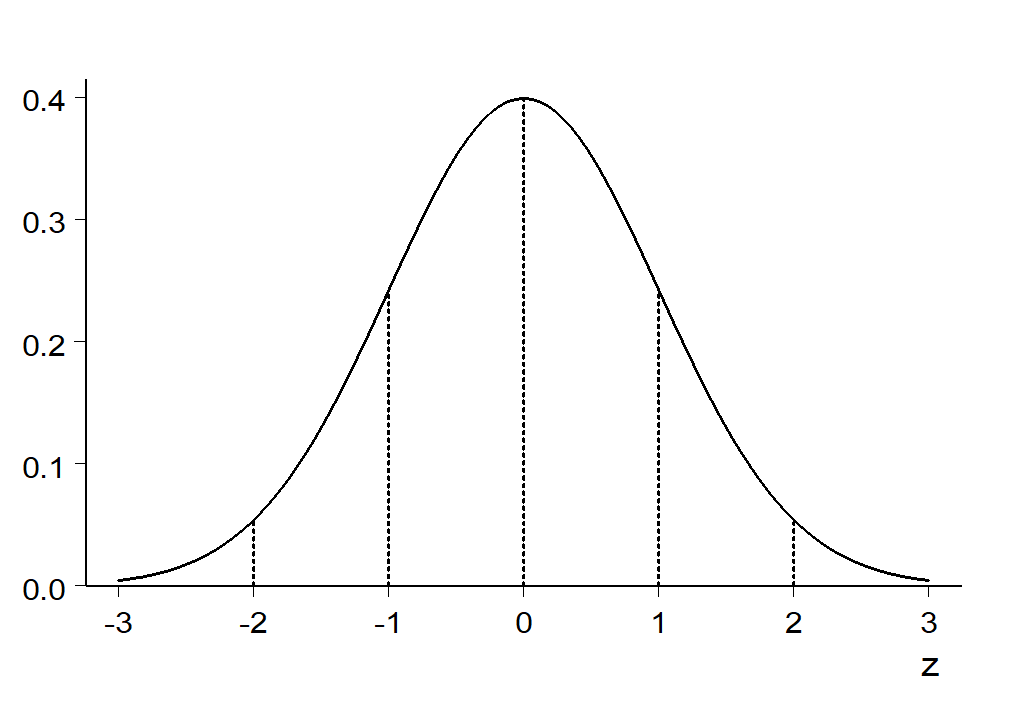

## X to Z and vice versa

You can standardize values of any normally distributed variable

$$Z = \frac{X-\mu_x}{\sigma_x}$$

**Standardizing:** Removing the original units of measurement

And reverse it to get the units back; for any Z-value:

$$X = \mu_x + (Z\times\sigma_x)$$

## Properties of the Normal Distribution (1 / 4)

- The distribution is symmetric

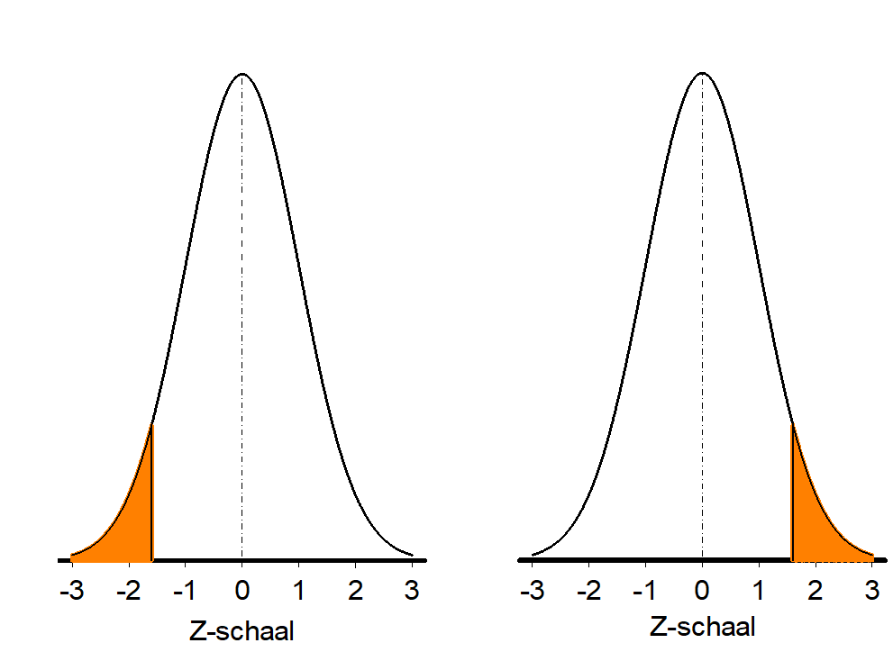

$P(Z < -1.64) = P(Z > 1.64) = 0.05$

## Properties of the Normal Distribution (2 / 4)

- Total surface area is 1
- We can find areas by taking the complement (1-something)

$P(Z < 1.64) = .95$

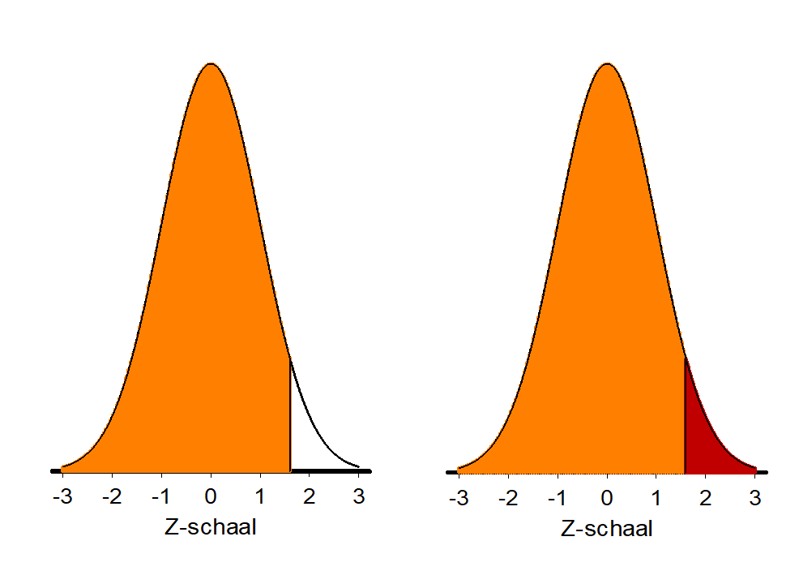

So $P(Z > 1.64) = 1-.95 = .05$

## Properties of the Normal Distribution (3 / 4)

- Areas can be added

$P(Z > 0) = .5$

$P(-.5< Z < 0) = .19$

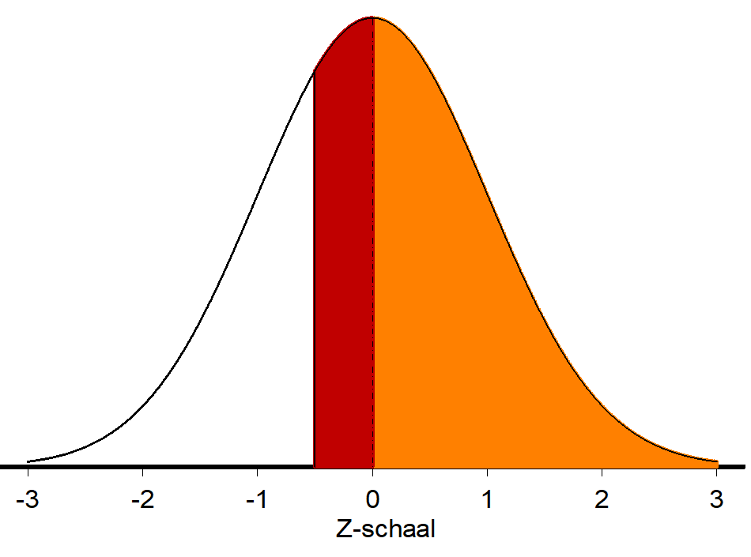

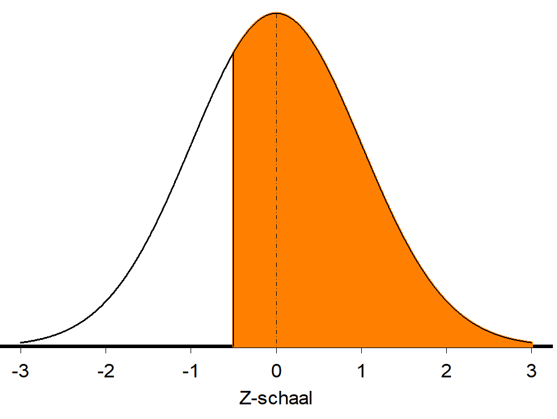

So $P(Z > -.5) = .5+.19 = .69$

## Properties of the Normal Distribution (4 / 4)

Standard percentages for mean, +/- 1, 2, 3 SD

- 50% of distribution is below $\mu$, 50% above

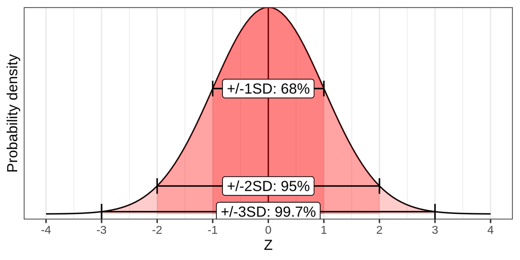

## Percentiles

The $k$-th percentile is the score below which $k$ percent of scores fall

So in the standard normal distribution:

- The mean/median is the 50th percentile, because $P(Z < 0) = .5$
- We call the 25th and 75th percentile the first and third *quartile*
- +1SD is the 84th percentile, because $P(Z < 1) = .84$

## Percentiles for X-scores

Let’s apply this to $IQ \sim N(\mu = 100, \sigma = 15)$

- What percentile corresponds to IQ < 120?
- $Z = \frac{120-100}{15} = 1.33$
- $P(Z<1.33) \approx .90$, so 90th percentile

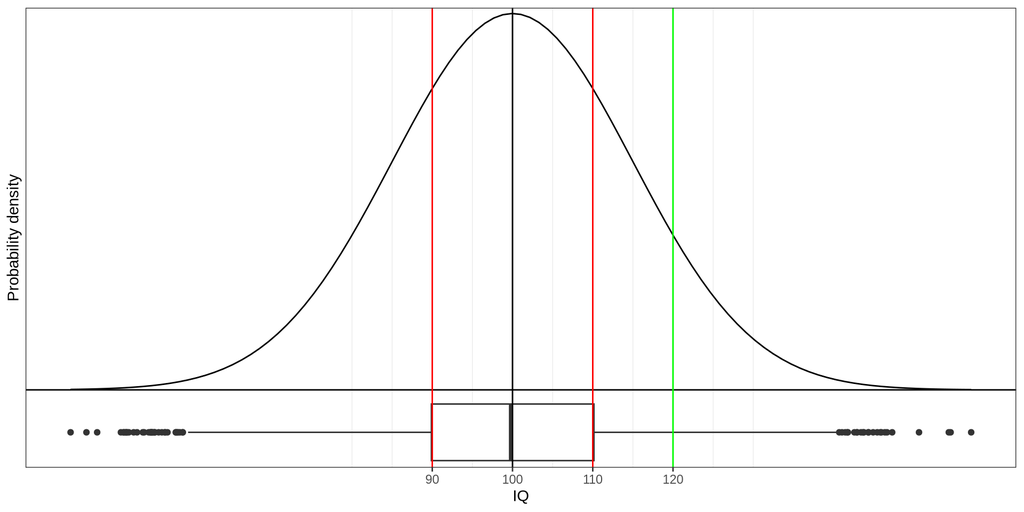

# Describing data

## A simple model

We can use the normal distribution as a *model* for the distribution of an observed variable

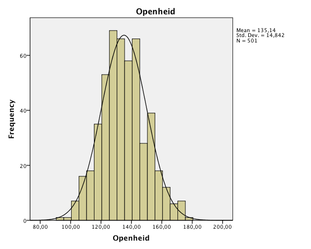

## A simple model

“We assume variable X to be normally distributed”

This allows us to:

- Summarize people’s values with just a mean and SD
- Calculate probabilities of observing certain scores using table

## Models can be wrong

Of course, the assumption can be wrong

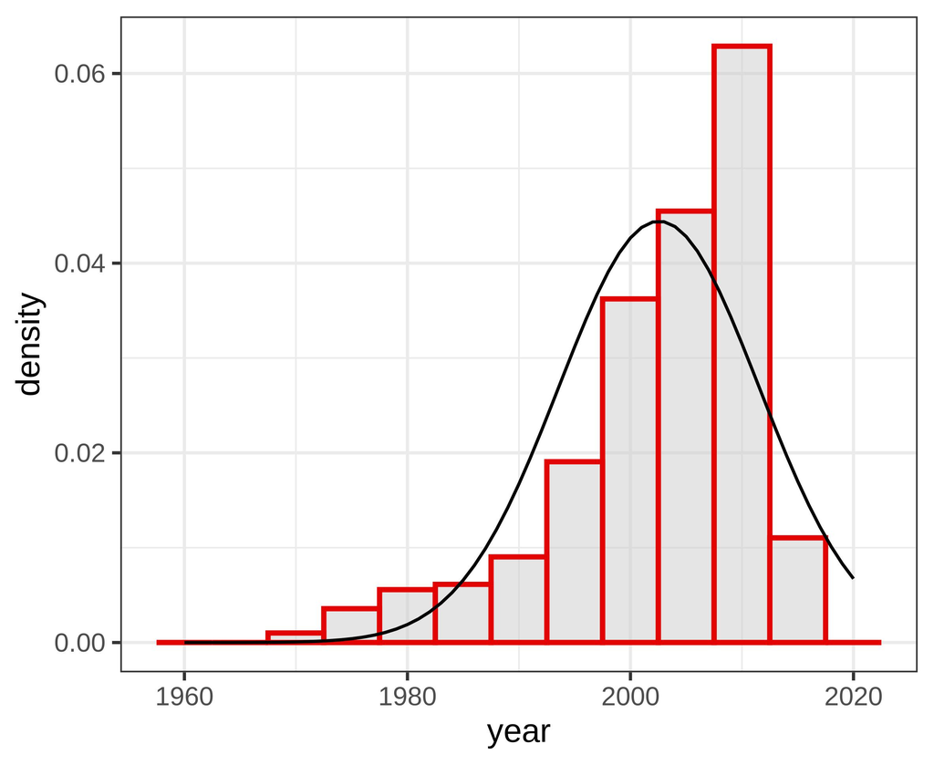

- “All models are wrong, but some are useful” (Box)
- In this example, mean, SD, and probabilities are going to misrepresent our data
  - Normal model it not very useful

## What if the model is wrong?

Solution:

- Choose a different probability distribution (not part of this course)
- “Transform” the data to become “more normal”
- Comment that the assumption of normality may be violated (e.g., in Discussion section)